# Field Baker’s day at campus

Jaime Duran

5/5/2020

Young Field Baker is planning his trip to CSUB campus. He must make 5 stops and one visit to a restroom. He starts and ends the day at the bus stop on campus

The stops he must make and the North, East coordinates of each are givnen in the following table: (units are Cubits)

| Location | coordinates (N, W) |
| --- | --- |
| Bus stop | 25, 200 |
| Engineering Complex | 110, 160 |
| Dorthy Donahue Building | 250, 200 |
| Student Union | 250, 300 |
| Walter Stern Library | 300, 250 |
| Administration Building | 260 , 50 |

In addition he must one stop at a restroom; the available restrooms are at locations (200,160), (340,110), and (280,290)

Find the shortest route freshman Field can take on this visit. Only 1 restroom stop

## Answer

The freshman will arrive at the Bus Stop and walk in a counter-clockwise path. Begining from the Bus Stop (25,200) walk to the Student Union Builing (250, 300). From the Student Union the student can walk towards a restroom located at (280,290) then continue walking towards the Walter Stern Library (300, 250). From the library the student should stop by Dorthey Donahue Hall (250, 200). Afterwards the fresmhen can visit the Administration Building (260, 50) and the Engineering Complex (110, 160) . After leaving the engineering complex, the student will arrive back at the Bus Stop (25, 200).

```r
x = c(200, 160, 200,300,250,50)
y = c(25, 110, 250, 250, 300, 260)
```

```r
tourMAT = ETSP(data.frame(x, y))
tourSolve = solve_TSP(tourMAT)
tour_length(tourSolve)
```

```
## [1] 817.928
```

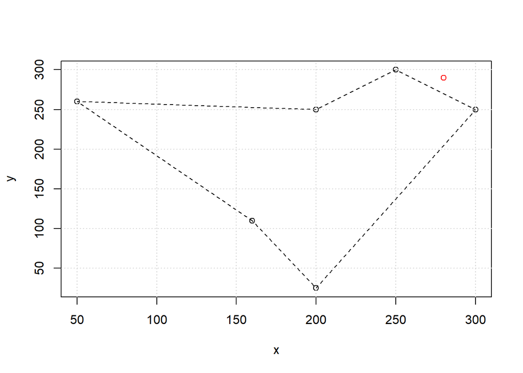

```r
plot(tourMAT, tourSolve )
points(280, 290, col=2 )
grid()
```